# 意思決定分析と予測の活用｜第2部 決定分析の基礎

https://logics-of-blue.com/decision-analysis-and-forecast-book-support/

## 第6章 情報の価値

### 6.1 Pythonによる分析の準備

```python
# 数値計算に使うライブラリ
import numpy as np
import pandas as pd
from IPython.display import Image

# DataFrameの全角文字の出力をきれいにする
pd.set_option('display.unicode.east_asian_width', True)
# 本文の数値とあわせるために、小数点以下3桁で丸める
pd.set_option('display.precision', 3)
```

```python
# 最大値をとるインデックスを取得する。最大値が複数ある場合はすべて出力する。
def argmax_list(series):
    return(list(series[series == series.max()].index))
```

```python
# 期待金額最大化に基づく意思決定を行う関数
def max_emv(probs, payoff_table):
    """
    :param probs: pandas.DataFrame
        同時確率分布
    :param payoff_table: pandas.DataFrame
        利得行列
    :return: pandas.Series
        選択肢と期待金額を返す
    """
    emv = payoff_table.mul(probs, axis=0).sum()
    max_emv = emv.max()
    a_star = argmax_list(emv)
    return(pd.Series([a_star, max_emv], index=['選択肢', '期待金額']))
```

### 6.2 意思決定問題の構成要素

$ D = \{ A, \Theta, F, c, P(\theta, f)\} $

$A: 選択肢の有限集合$  
$\Theta: 自然状態の有限集合$  
$F: 情報の有限集合$  
$c: 選択肢と自然の状態が決まったときの利得$  
$P(\theta, f): 自然の状態と情報の同時分布$

### 6.3 今回扱う事例

- 例によって前章から同じ事例
- 0台稼働と1台稼働、1台稼働のほうが優越しているので、0台稼働は除外
  - 優越とは：ある選択肢Aが、別の選択肢Bよりも常に好ましい結果を持つとき、Bを選ぶことを優越する決定という

#### 今回扱う利得行列

```python
Image("imgs/table_2_6_1.png")
```

[output not shown]

#### 自然の状態と予測値の同時確率分布 (joint probability distribution)

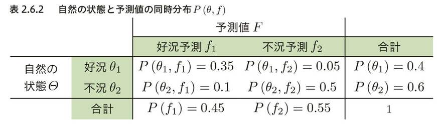

```python
Image("imgs/table_2_6_2.png")
```

#### 自然の状態と予測値に対する条件付き分布 $P(\theta | f)$

- 条件付き確率は以下の通り
  - $P(\theta_i | f_k) = P(\theta, f_k) / P(f_k)$

```python
Image("imgs/table_2_6_3.png")
```

[output not shown]

### 6.2.3 Python実装：同時分布と利得行列

```python
# 利得行列
payoff = pd.DataFrame({
    '1台': [300, 300],
    '2台': [700, -300]
})
payoff.index = ['好況', '不況']
print(payoff)
```

```
      1台  2台
好況  300  700
不況  300 -300
```

```python
# 同時分布
joint_forecast_state = pd.DataFrame({
    '好況予測': [0.35, 0.1],
    '不況予測': [0.05, 0.5]
})
joint_forecast_state.index = ['好況', '不況']
print(joint_forecast_state)
```

```
      好況予測  不況予測
好況      0.35      0.05
不況      0.10      0.50
```

### 6.2.4 Python実装：周辺分布と条件付き分布

#### 周辺分布を求める

```python
# 予測の周辺分布
marginal_forecast = joint_forecast_state.sum(axis=0)
marginal_forecast
```

```
好況予測    0.45
不況予測    0.55
dtype: float64
```

```python
# 自然の状態の周辺分布
marginal_state = joint_forecast_state.sum(axis=1)
marginal_state
```

```
好況    0.4
不況    0.6
dtype: float64
```

#### 条件付分布を求める

```python
# 予測が得られた後の条件付き分布
conditional_forecast = joint_forecast_state.div(marginal_forecast, axis=1)
print(conditional_forecast)
```

```
      好況予測  不況予測
好況     0.778     0.091
不況     0.222     0.909
```

#### 6.3 条件付き期待値に基づく意思決定

- 情報が与えられたときの意思決定の方針 → **期待金額を最大にする選択肢を選ぶ**方針

##### 前提

- 情報($f$)が、自然の状態($\theta$)と独立では**ない** という前提で考える
  - 要するに、情報がなんらかの役に立っている状況を前提とする(=予測がちゃんと予測できてる、という前提)
- 独立ではないので、$P(\theta | f) \neq P(\theta)$ という状況
- 情報が役に立ってるのであれば、$P(\theta|f)$ を使って意思決定したほうがよいので、$P(\theta|f)$ を使う
  - 本の言い回し「(前略)独立ではないので$P(\theta | f) \neq P(\theta)$。そこで、$P(\theta)$ の代わりに $P(\theta|f)$ を使う」がわかってないが、上述の理解をしている

#### 6.3.2 数式による表現

条件付き分布を使った期待金額は、以下の計算式になる。

- ある選択肢$a_j$の条件付き期待金額(期待値)
  - $ EMV(a_j|P(\theta|f_k)) = \sum_{i=1}^{\#\Theta} P(\theta_i|f_k) \cdot c(a_j, \theta_i)$
- 上述の各選択肢ごとの期待金額を算出し、最大の期待金額となる選択肢$a^*_{f_k}$を選べば、期待金額が最大化される
  - $a^*_{f_k} = \underset{a_j}{argmax}EMV(a_j|P(\theta|f_k))$

ここでは条件付き確率分布 $P(\theta|f)$ しか使ってない(だって条件付き期待金額のことしか考えてないからね)  
ただ、予測の価値を評価するときは、同時分布 $P(\theta, f)$ が必要になってくるらしいよ。

#### 6.3.2 数値例

実際の数字を入れて確認していくよ。

- 下記の表を使うと出せるよ。

```python
Image("imgs/table_2_6_1.png")
```

[output not shown]

```python
Image("imgs/table_2_6_3.png")
```

[output not shown]

#### 6.3.4 Python実装

手計算とあったね。

```python
info_decision = \
    conditional_forecast.apply(max_emv, axis=0, payoff_table=payoff)
print(info_decision)
```

```
         好況予測 不況予測
選択肢      [2台]    [1台]
期待金額  477.778    300.0
```

### 6.4 情報を使わない意思決定との比較

ここからが **情報の価値** の解説。

- 情報の価値とは
  - 情報を使って意思決定したときの評価値(ex:期待金額)と、情報を使わないで意思決定したときの評価値の差分
  - ちなみに、評価値に期待値以外を使ってもいいんだよ

#### 情報を使わないで意思決定した場合を計算

情報がない。つまり、好況予報とか、不況予報とかの情報を入れずに判断するので、  
自然状態の確率分布(=周辺確率分布？)で判断することになる。  
なので、周辺分布に対して、利得行列との掛け合わせで算出すればよいので、以下の計算でOK。

不況になる確率がちょい大きいので、その時にマイナスになる2台稼働を選ぶと期待値が下がるので、1台稼働が選ばれるね。

```python
naive_decision = max_emv(marginal_state, payoff)
naive_decision
```

```
選択肢      [1台]
期待金額    300.0
dtype: object
```

```python
emv_naive = naive_decision['期待金額']
print(f'予測を使わないときの期待金額: {emv_naive:.3g}万円')
```

```
予測を使わないときの期待金額: 300万円
```

### 6.5 情報の価値：事後分析

ここで実際に、情報の価値(=情報が与えられたときの期待金額と、与えられなかったときの期待金額の差分)を出してみる。

#### 6.5.1 定義

- 情報の事後価値(独自用語)
  - 情報が得られたあとの情報の価値
- 事後分析
  - 事後価値を評価すること

ま、結局さっきから言ってる通り、「情報が与えられたときの期待金額と、与えられなかったときの期待金額の差分」ってことよ。  
数式で書くと以下の通り。

$V_k = EMV(a^*_{f_k} | P(\theta|f_k)) - EMV(a^*| P(\theta))$

#### 6.5.2 数値例(実際に手計算してみる)

- $k=1$ で好況予報が出ているとき
  - $V_{f_1} = EMV(a^*_{f_1}|P(\theta|f_1)) - EMV(a^*|P(\theta))$
  - 好況予報のときは、「$a^*_{f_1}$ = 2台稼働」で、それはすでに算出済。478。
  - 好況予報、不況予報わからないとき(=情報が与えられてないとき)の期待金額は、「1台稼働」で300とわかってますよね
  - なので、$上述式 = 478 - 300 = 178$
- $k=2$ で不況予報が出ているとき
  - $V_{f_2} = EMV(a^*_{f_2}|P(\theta|f_2)) - EMV(a^*|P(\theta))$
  - $ = 300 - 300 $
  - 不況のとき、最適な選択肢は「1台稼働」で、情報が無い時と同じ選択肢になる
  - つまり、「情報があってもなくても、選択肢は同じ」なので、情報に価値がない、という判断になり、事後価値も0となっている

#### 6.5.4 Python実装

まずは、好況予報のとき。

```python
post_value_boom = info_decision.loc['期待金額', '好況予測'] - emv_naive
print(f'好況予測が出たときの期待金額の差: {post_value_boom:.3g}万円')
```

```
好況予測が出たときの期待金額の差: 178万円
```

不況予報のとき

```python
post_value_slump = info_decision.loc['期待金額', '不況予測'] - emv_naive
print(f'不況予測が出たときの期待金額の差: {post_value_slump:.3g}万円')
```

```
不況予測が出たときの期待金額の差: -5.68e-14万円
```

不況予報のときは、$e-14 = 10^{-14}$ なので、ほぼゼロ。

### 6.6 情報の価値：事前分析

情報が得られる前に、その情報の価値を評価したいことって、あるよね。  
情報の価値が高いなら、それなりの費用を投じてその情報を得るけど、情報の価値が低いなら見送りたいよね。  
つまり、実際のその情報を手にする以前に、その価値を知りたい、と。

そんな「情報を得るまえの情報の価値」の出し方を教えてくれるらしい(多分)

- **情報の事前価値** とは
  - 情報が得られる前の、平均的な情報の価値
- **事前分析**とは
  - 事前価値を評価すること

この本では、「情報の価値=事前情報価値」とするよ。

#### 6.6.1 定義

情報が与えられる予定のときの最大期待金額を求める。

- $EMV(a^*_f | P(\theta, f)) = \sum_{k=1}^{\#F} P(f_k) \cdot EMV(a^*_{f_k}|P(\theta|f_k))$
  - 意味
    - 好況予測$f_1$が出たときの条件付き期待金額と、不況予測$f_2$が出たときの条件付期待金額に対して、予測の周辺分布 $P(f)$ をかけたもの。これが
- $= \sum_{k=1}^{\#F}P(f_k) \sum_{i=1}^{\#\Theta}P(\theta_i|f_k) \cdot c(a_{f_k}^*, \theta_i)$
  - 期待金額 $EMV(a^*_{f_k}|P(\theta|f_k))$の定義より
- $= \sum_{i=1}^{\#\Theta} \sum_{k=1}^{\#F} P(\theta_i, f_k) \cdot c(a_{f_k}^*, \theta_i)$
  - 条件付き確率の定義：$P(f_k) \cdot P(\theta_i|f_k) = P(\theta_i, f_k)$ を利用
  - 条件付き確率を使わなくても、同時分布(joint distribution)だけで算出できるよ

この時の事前価値は以下になる。

$V_f = EMV(a^*_f|P(\theta, f)) - EMV(a^*|P(\theta))$

##### 事後価値と事前価値の違い

- 事後価値
  - $V_k = EMV(a^*_{f_k} | P(\theta|f_k)) - EMV(a^*| P(\theta))$
- 事前価値
  - $V_f = EMV(a^*_f|P(\theta, f)) - EMV(a^*|P(\theta))$
- 違い
  - 事後価値は、好況予測の時、不況予測の時($f_k$)、それぞれに対応する事後価値が出てくる
    - 好況予測下の事後価値は178万、不況予測下の事後価値は0万
  - 事前価値は、その予測自体($f$)に対する情報の価値が算出される
    - この後算出するけど、80万になる
  - 事前価値、の価値はどこにある？
    - たとえば、その予測(予報？好況予報、不況予報)を得るのにお金がかかる場合( ex:好況・不況予測するためのデータを集めるのにお金がかかる) いくらまでなら使ってもいいのか？を判断できる。予測を得る費用が80万以下ならやって良い。それ以上ならちょっと考えたほうがよい(やらないほうがよい、というわけでもない。。？)

#### 6.6.2 数値例

実際の数値を式にハメていく。

```python
Image("imgs/table_2_6_1.png")
```

[output not shown]

```python
Image("imgs/table_2_6_3.png")
```

[output not shown]

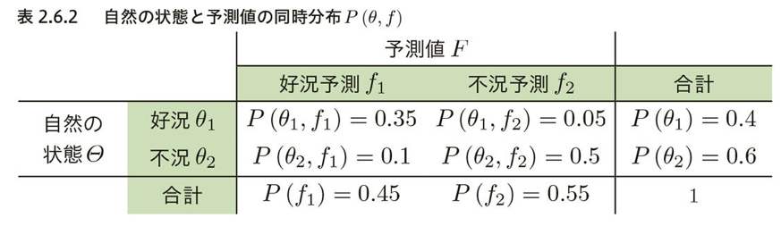

```python
Image("imgs/table_2_6_2.png")
```

$EMV(a^*_f | P(\theta,f)) = \sum_{k=1}^{\#F} P(f_k) \cdot EMV(a^*_{f_k}|P(\theta|f_k))$ $\approx 0.45 \times 478 + 0.55 \times 300$ $\approx 215 + 165 = 380 $

情報の事前価値 $V_f$ は以下で計算され、平均的には80万の価値があるとなる。  
$V_f = EMV(a^*_f | P(\theta, f)) - EMV(a^*|P(\theta))$ $= 380 = 300 = 80$

#### 6.6.3 Python実装

```python
emv_forecast = info_decision.loc['期待金額'].mul(marginal_forecast).sum()
print(f'情報を使ったときの期待金額: {emv_forecast:.3g}万円')
```

```
情報を使ったときの期待金額: 380万円
```

同時分布だけを使って出す場合のPython式。

```python
# 同時分布を使って計算しても良い
joint_forecast_state.apply(
    max_emv, axis=0, payoff_table=payoff).loc['期待金額'].sum()
```

```
380.0
```

事前価値の算出

```python
ante_value = emv_forecast - emv_naive
print(f'情報の価値: {ante_value:.3g}万円')
```

```
情報の価値: 80万円
```

### 6.7 完全情報と完全情報の価値

- **完全情報**とは
  - 自然の状態について確実に伝えてくれる情報のこと(意味不明)
  - 完全情報を得た後、自然の状態に対する情報エントロピー(情報の不確実性)は0

#### 6.7.1 定義

- 自然の状態がわかってる時に利得を最大にする選択肢を $a_{\theta_i}^*$ と表記。
- $a_{\theta_i}^*$ を取るときの期待金額 $EMV(a_\theta^*|P(\theta))$ は下記になる
  - $EMV(a^*_{\theta}|P(\theta)) = \sum_{i=1}^{\#\Theta} P(\theta_i) \cdot c(a^*_{\theta_i}, \theta_i)$
  - 予測とか何も関係なく、もう「自然の状態(好況/不況)」がわかってる時の最大期待金額。
  - $\#\Theta$ 個分の合計
  - $\theta$ にしか依存しない値
- 完全情報の事前価値
  - $V_{perfect} = EMV(a^*_{\theta}|P(\theta)) - EMV(a^*|P(\theta))$

##### 完全情報の事前価値、事前価値、事後価値

- 事後価値
  - $V_k = EMV(a^*_{f_k} | P(\theta|f_k)) - EMV(a^*| P(\theta))$
- 事前価値
  - $V_f = EMV(a^*_f|P(\theta, f)) - EMV(a^*|P(\theta))$
- 完全情報の事前価値
  - $V_{perfect} = EMV(a^*_{\theta}|P(\theta)) - EMV(a^*|P(\theta))$
- 違い
  - 事後価値は、好況予測の時、不況予測の時($f_k$)、それぞれに対応する事後価値が出てくる
    - 好況予測下の事後価値は178万、不況予測下の事後価値は0万
  - 事前価値は、その予測自体($f$)に対する情報の価値が算出される
    - この後算出するけど、80万になる
  - 事前価値、の価値はどこにある？
    - たとえば、その予測(予報？好況予報、不況予報)を得るのにお金がかかる場合( ex:好況・不況予測するためのデータを集めるのにお金がかかる) いくらまでなら使ってもいいのか？を判断できる。予測を得る費用が80万以下ならやって良い。それ以上ならちょっと考えたほうがよい(やらないほうがよい、というわけでもない。。？)
  - 完全情報の事前価値は、$\theta$ にしか依存しない。つまり、予測がどうこうとか全然関係なく、自然の状態がどれになるかわかってる状態の時の期待金額を出すことでその価値を算出している

```python
# 自然の状態別の最大利得
payoff.max(axis=1)
```

```
好況    700
不況    300
dtype: int64
```

$\sum_{i=1}^{\#\Theta} P(\theta_i) \cdot c(a^*_{\theta_i}, \theta_i)$ の計算を実際にさせると460万になる。

```python
# 自然の状態にあわせて利得を最大にする行動をとったときの期待金額
emv_perfect = payoff.max(axis=1).mul(marginal_state).sum()
emv_perfect
```

```
460.0
```

$\sum_{i=1}^{\#\Theta} P(\theta_i) \cdot c(a^*_{\theta_i}, \theta_i)$ から、情報を使わないで意思決定した時の期待金額 $EMV(a^*|P(\theta))$ を引くと、 完全情報の価値が得られる。

```python
perfect_information_value = emv_perfect - emv_naive
print(f'完全情報の価値: {perfect_information_value:.3g}万円')
```

```
完全情報の価値: 160万円
```

### 6.8 情報の価値の比較

工場の機械稼働以外の例を使って、予測に対しての情報価値の計算をしてみる。

#### 6.8.1 コイン投げ予測の情報の価値

- コイン投げて表なら好況、裏なら不況」という情報の場合、相互上昇量で測定した情報量は0だった
  - 情報と自然の状態が独立である場合、情報量は0、というわけ
  - 情報が何も情報を与えないのと同じだもんね
- 情報と自然の状態が独立である場合、$P(\theta_i|f_k) = P(\theta_i)$ となる。
  - この時、すべての $k$ において $EMV(a_j|P(\theta|f_k)) = EMV(a_j|P(\theta))$が成立する
  - つまり、情報があってもなくて期待金額が変わらない。= コイン投げの結果が持つ情報の価値はゼロ

ここまでをPythonを使って確認する。

まずは同時分布を用意する。

```python
# 「コインを投げて表なら好況、裏なら不況と主張する」情報
coin_result = pd.DataFrame({
    '好況予測': [0.2, 0.3],
    '不況予測': [0.2, 0.3]
})
coin_result.index = ['好況', '不況']
print(coin_result)
```

```
      好況予測  不況予測
好況       0.2       0.2
不況       0.3       0.3
```

コイン投げの結果を使った時の期待金額を実際に集計してみると、下記のようになり、結果は300万。 これは、情報を使わないで意思決定した時の期待金額と変わらないので、コイン投げによって得られる情報に価値は無い、となる。

```python
# コイン投げの結果を使ったときの期待金額
emv_coin = coin_result.apply(
    max_emv, axis=0, payoff_table=payoff).loc['期待金額'].sum()
emv_coin
```

```
300.0
```

#### 6.8.2 天の邪鬼予測の情報の価値

「予測が常に真逆になる」という状況で、情報の価値を計算してみる。

- [結論]
  - 完全情報と全く同じになる
    - 実際に計算してみると、460万になる
  - 不況と予測されれば機会をたくさん動かし、好況と予測された時には機械を動かさないで生産数を絞る、という、あべこべな行動を取ることでも期待金額は増やせる
    - なんでやねん

Pythonで確認してみる。

```python
# 予測値と実測値が常に逆になる情報
perversity_forecast = pd.DataFrame({
    '好況予測': [0, 0.6],
    '不況予測': [0.4, 0]
})
perversity_forecast.index = ['好況', '不況']
print(perversity_forecast)
```

```
      好況予測  不況予測
好況       0.0       0.4
不況       0.6       0.0
```

```python
# 予測値と実測値が常に逆になる情報を使ったときの期待金額
emv_perversity = perversity_forecast.apply(
    max_emv, axis=0, payoff_table=payoff).loc['期待金額'].sum()
emv_perversity
```

```
460.0
```

### 6.9 情報の有効性

- 情報の品質が悪い場合は、情報を無視して意思決定するだけなので、情報の価値(情報を使った時の期待金額と、情報を使ってない時の期待金額の差分)が負になることはない
- 情報の価値が、完全情報(どの自然状態になるかわかってる時の価値)よりも大きくなることもない

上記のことより以下が成立する

$0 \leq V_f \leq V{perfect}$

情報の価値を、完全情報の価値でわった比率=**情報の有効性** と呼ぶ。

$efficiency = \frac{V_f}{V_{perfect}}$

Pythonで算出してみる

- 0.5ってでるけど、これの解釈はどうするんだろうか。

```python
efficiency = ante_value / perfect_information_value
print(f'情報の有効性: {efficiency:.3g}')
```

```
情報の有効性: 0.5
```

### 6.10 期待リグレットと不確実性の費用

情報はどんなシチュエーションで価値を生み出すのか？ の答えを考えてみる。

#### 復習

- リグレット(機会損失)とは
  - 自然の状態ごとに見た最大利得と比較した差額
  - $r(a_j, \theta_i) = c(a^*_{\theta_j}, \theta_i) - c(a_j, \theta_i)$
    - とある自然の状態において、その自然の状態の最大利得と、任意の利得との差がリグレット

#### 期待リグレット とは

- 定義式
  - $R(a_j|P(\theta)) = \sum_{i=1}^{\#\Theta} P(\theta_i) \cdot r(a_j, \theta_i)$
  - $ = \sum_{i=1}^{\#\Theta} P(\theta_i) \cdot [c(a^*_{\theta}, \theta_i) - c(a_j, \theta_i)]$
    - リグレットの定義式を代入して変換した状態
  - $ = \sum_{i=1}^{\#\Theta} [P(\theta_i) \cdot c(a^*_{\theta}, \theta_i)] - \sum_{i=1}^{\#\Theta} [ P(\theta_i) \cdot c(a_j, \theta_i) ]$
    - 大かっこを分配
  - $ = EMV(a_{\theta}^*|P(\theta)) - EMV(a_j|P({\theta})) $
- 完全情報を使って意思決定した時の期待金額 $EMV(a_{\theta}^*|P(\theta))$ と、 ある行動 $a_j$ をとった時の期待金額 $EMV(a_j|P({\theta}))$ の差。
- 期待金額$EMV(a_j|P({\theta}))$を最大にする行動は、期待リグレットを最小にする行動になる
- 情報が得られない状況の場合、$EMV(a_j|P(\theta))$ を最大にする選択肢 $a^*$ を採用するよね。この時の期待リグレットは、完全情報そのもの
  - 期待リグレット： $EMV(a_{\theta}^*|P(\theta)) - EMV(a_j|P({\theta})) $
  - 完全情報の事前価値： $EMV(a_{\theta}^*|P(\theta)) - EMV(a_j|P({\theta})) $
  - $V_{perfect} = EMV(a^*_{\theta}|P(\theta)) - EMV(a^*|P(\theta))$
- つまり、完全情報の事前価値とは
  - = 自然の状態がわからない中で、期待金額を最大にするための最善を尽くした際に発生してしまう、期待リグレットの大きさ
  - = その情報をえるために支払うことのできる最大の費用
- 仮に、自然の状態に不確実性が一切無い場合(=確実に好況/不況が読める場合)、とくに好況予測/不況予測にお金を使う必要はないよね
- 完全情報の事前価値 = 不確実なものをできるだけ確実にするための情報(好況予測/不況予測)を得るために使える最大費用 → 不確実性の費用
  - 不確実性の費用 ： 多分、「不確実性に対して可能な限り確実な判断をするために必要な情報を得るのに使ってよい最大費用」、略して、不確実性の費用
- 不確実性の費用が大きい = 不確実な状態をできるだけ確実な状況にした時に得られる期待金額 → 不確実性の費用が大きいほど、情報としての価値が高い

### 6.11 情報の価値の定義に関する考察

なんかルサンチマン話してるやつ。 (時間とれず、まとめてないです)

### 6.12 記号の整理

省略